# Scientific Names tool comparison

This notebook is part of ENVRI FAIR WP11 use case on scientific names and FAIR data. The goal is to document how different tools provide different responses for the same scientific name.

The following small test dataset (plants) were generated to highlight some of the issues.

| scientificName | Notes |
| --- | --- |
| Pinus mugo Turra | Correct and accepted name |
| Pinus mugo | Exclude the author name |
| Pinus mugo Smith | Wrong author name |
| Pinus muco Turra | Spelling mistake |
| Pino mugo Turra | Wrong genus |
| Pinus basso Turra | Wrong species |

## Services

**Global Names Resolver**

http://resolver.globalnames.org/

From the Global Names Index (GNI) project which queries multiple taxonomic backbone and services. More here: https://globalnames.org/

**GBIF**

https://gbif.org Global Biodiveristy Information Facility Python Library

**Catalogue of Life**

Name-match tool https://data.catalogueoflife.org/tools/name-match

**LifeWatch Data services**

https://lifewatch.be/data-services/

## Outputs

### Global Names Resolver

*Pinus mugo Turra*

Accepted name with the binomials and author name (the person credited with the first formal use of the name)

```python
import requests
from pprint import pprint
import json
from requests.structures import CaseInsensitiveDict
url = "http://resolver.globalnames.org/name_resolvers.json?names=Pinus+mugo+Turra"
headers = CaseInsensitiveDict()
headers["Accept"] = "application/json"

resp = requests.get(url, headers=headers)
# data_source_title shows the source name
for i in json.loads(resp.text)['data']:
    pprint(i['results'])
```

```
[{'canonical_form': 'Pinus mugo',
  'classification_path': 'Biota|Plantae|Tracheophyta|Pinopsida|Pinales|Pinaceae|Pinus|Pinus '
                         'mugo',
  'classification_path_ids': '5T6MX|P|TP|GG|623FD|625M7|6QPY|4J2CJ',
  'classification_path_ranks': 'unranked|kingdom|phylum|class|order|family|genus|species',
  'data_source_id': 1,
  'data_source_title': 'Catalogue of Life Checklist',
  'edit_distance': 0,
  'gni_uuid': 'b5948654-7d7c-5eb0-874b-a3a00dd07c3b',
  'imported_at': '2021-11-20T18:28:02Z',
  'match_type': 1,
  'match_value': 'Exact string match',
  'name_string': 'Pinus mugo Turra',
  'prescore': '8|0|0',
  'score': 0.999,
  'taxon_id': '4J2CJ'},
 {'canonical_form': 'Pinus mugo',
  'classification_path': 'Plantae|Viridiplantae|Streptophyta|Embryophyta|Tracheophyta|Spermatophytina|Pinopsida|Pinidae|Pinales|Pinaceae|Pinus|Pinus '
                         'mugo',
  'classification_path_ids': '202422|954898|846494|954900|846496|846504|500009|954916|500028|18030|18035|183358',
  'classification_path_ranks': 'Kingdom|Subkingdom|Infrakingdom|Superdivision|Division|Subdivision|Class|Subclass|Order|Family|Genus|Species',
  'data_source_id': 3,
  'data_source_title': 'Integrated Taxonomic Information SystemITIS',
  'edit_distance': 0,
  'gni_uuid': 'b5948654-7d7c-5eb0-874b-a3a00dd07c3b',
  'imported_at': '2021-12-08T23:04:11Z',
  'match_type': 1,
  'match_value': 'Exact string match',
  'name_string': 'Pinus mugo Turra',
  'prescore': '8|0|0',
  'score': 0.999,
  'taxon_id': '183358'},
 {'canonical_form': 'Pinus mugo',
  'classification_path': 'Plant|Pinaceae|Pinus|Pinus mugo',
  'classification_path_ids': '1000p|879f|9418g|28493s',
  'classification_path_ranks': '|||',
  'data_source_id': 6,
  'data_source_title': 'GRIN Taxonomy for Plants',
  'edit_distance': 0,
  'gni_uuid': 'b5948654-7d7c-5eb0-874b-a3a00dd07c3b',
```

[output cut: 553 more lines]

```
  'classification_path_ranks': 'kingdom|',
  'data_source_id': 169,
  'data_source_title': 'uBio NameBank',
  'edit_distance': 0,
  'global_id': 'urn:lsid:ubio.org:namebank:1882142',
  'gni_uuid': '5f8334ef-cc2b-58b6-89ef-fe701e0b9187',
  'imported_at': '2013-05-31T14:45:02Z',
  'local_id': 'urn:lsid:ubio.org:namebank:1882142',
  'match_type': 2,
  'match_value': 'Exact match by canonical form',
  'name_string': 'Pinus mugo Compacta',
  'prescore': '3|-2|0',
  'score': 0.75,
  'taxon_id': '95161160',
  'url': 'http://www.ubio.org/browser/details.php?namebankID=1882142'}]
```

Now *Pinus mugo*

Excluding the author name, only the binomials.

```python
import requests
from pprint import pprint
import json
from requests.structures import CaseInsensitiveDict
url = "http://resolver.globalnames.org/name_resolvers.json?names=Pinus+mugo"
headers = CaseInsensitiveDict()
headers["Accept"] = "application/json"

resp = requests.get(url, headers=headers)
# data_source_title shows the source name
for i in json.loads(resp.text)['data']:
    pprint(i['results'])
```

```
[{'canonical_form': 'Pinus mugo',
  'classification_path': '',
  'classification_path_ids': '',
  'classification_path_ranks': '',
  'data_source_id': 2,
  'data_source_title': 'Wikispecies',
  'edit_distance': 0,
  'gni_uuid': '2f24b92e-3f06-5367-a0c0-d1458e41d533',
  'imported_at': '2021-12-08T22:35:52Z',
  'match_type': 1,
  'match_value': 'Exact string match',
  'name_string': 'Pinus mugo',
  'prescore': '3|0|0',
  'score': 0.988,
  'taxon_id': '45069',
  'url': 'http://species.wikimedia.org/wiki/Pinus_mugo'},
 {'canonical_form': 'Pinus mugo',
  'classification_path': '|Eukaryota|Viridiplantae|Streptophyta|Streptophytina|Embryophyta|Tracheophyta|Euphyllophyta|Spermatophyta|Acrogymnospermae|Pinopsida|Pinidae|Conifers|Pinales|Pinaceae|Pinus|Pinus|Pinus '
                         'mugo',
  'classification_path_ids': '131567|2759|33090|35493|131221|3193|58023|78536|58024|1437180|58019|3313|2821352|1446380|3318|3337|139271|28528',
  'classification_path_ranks': '|superkingdom|kingdom|phylum|subphylum|clade|clade|clade|clade|clade|class|subclass|clade|order|family|genus|subgenus|species',
  'data_source_id': 4,
  'data_source_title': 'National Center for Biotechnology Information',
  'edit_distance': 0,
  'gni_uuid': '2f24b92e-3f06-5367-a0c0-d1458e41d533',
  'imported_at': '2021-12-09T00:31:34Z',
  'match_type': 1,
  'match_value': 'Exact string match',
  'name_string': 'Pinus mugo',
  'prescore': '3|0|0',
  'score': 0.988,
  'taxon_id': '28528'},
 {'canonical_form': 'Pinus mugo',
  'classification_path': 'Pinus mugo',
  'classification_path_ids': '/en/mountain_pine',
  'classification_path_ranks': '',
  'data_source_id': 10,
  'data_source_title': 'Freebase',
  'edit_distance': 0,
  'gni_uuid': '2f24b92e-3f06-5367-a0c0-d1458e41d533',
```

[output cut: 553 more lines]

```
 {'canonical_form': 'Pinus mugo',
  'classification_path': 'Tracheophyta|Pinales|Pinaceae|Pinus mugo',
  'classification_path_ids': '',
  'classification_path_ranks': 'phylum|order|family|',
  'data_source_id': 198,
  'data_source_title': 'The Leipzig Catalogue of Vascular Plants',
  'edit_distance': 0,
  'gni_uuid': 'b5948654-7d7c-5eb0-874b-a3a00dd07c3b',
  'imported_at': '2021-12-30T17:42:27Z',
  'match_type': 2,
  'match_value': 'Exact match by canonical form',
  'name_string': 'Pinus mugo Turra',
  'prescore': '3|0|0',
  'score': 0.988,
  'taxon_id': 'gn-b5948654-7d7c'}]
```

*Pinus mugo Smith*

Wrong author name

```python
import requests
from pprint import pprint
import json
from requests.structures import CaseInsensitiveDict
url = "http://resolver.globalnames.org/name_resolvers.json?names=Pinus+mugo+Smith"
headers = CaseInsensitiveDict()
headers["Accept"] = "application/json"

resp = requests.get(url, headers=headers)
# data_source_title shows the source name
for i in json.loads(resp.text)['data']:
    pprint(i['results'])
```

```
[{'canonical_form': 'Pinus mugo',
  'classification_path': '',
  'classification_path_ids': '',
  'classification_path_ranks': '',
  'data_source_id': 2,
  'data_source_title': 'Wikispecies',
  'edit_distance': 0,
  'gni_uuid': '2f24b92e-3f06-5367-a0c0-d1458e41d533',
  'imported_at': '2021-12-08T22:35:52Z',
  'match_type': 2,
  'match_value': 'Exact match by canonical form',
  'name_string': 'Pinus mugo',
  'prescore': '3|0|0',
  'score': 0.988,
  'taxon_id': '45069',
  'url': 'http://species.wikimedia.org/wiki/Pinus_mugo'},
 {'canonical_form': 'Pinus mugo',
  'classification_path': '|Eukaryota|Viridiplantae|Streptophyta|Streptophytina|Embryophyta|Tracheophyta|Euphyllophyta|Spermatophyta|Acrogymnospermae|Pinopsida|Pinidae|Conifers|Pinales|Pinaceae|Pinus|Pinus|Pinus '
                         'mugo',
  'classification_path_ids': '131567|2759|33090|35493|131221|3193|58023|78536|58024|1437180|58019|3313|2821352|1446380|3318|3337|139271|28528',
  'classification_path_ranks': '|superkingdom|kingdom|phylum|subphylum|clade|clade|clade|clade|clade|class|subclass|clade|order|family|genus|subgenus|species',
  'data_source_id': 4,
  'data_source_title': 'National Center for Biotechnology Information',
  'edit_distance': 0,
  'gni_uuid': '2f24b92e-3f06-5367-a0c0-d1458e41d533',
  'imported_at': '2021-12-09T00:31:34Z',
  'match_type': 2,
  'match_value': 'Exact match by canonical form',
  'name_string': 'Pinus mugo',
  'prescore': '3|0|0',
  'score': 0.988,
  'taxon_id': '28528'},
 {'canonical_form': 'Pinus mugo',
  'classification_path': 'Pinus mugo',
  'classification_path_ids': '/en/mountain_pine',
  'classification_path_ranks': '',
  'data_source_id': 10,
  'data_source_title': 'Freebase',
  'edit_distance': 0,
  'gni_uuid': '2f24b92e-3f06-5367-a0c0-d1458e41d533',
```

[output cut: 553 more lines]

```
 {'canonical_form': 'Pinus mugo',
  'classification_path': 'Tracheophyta|Pinales|Pinaceae|Pinus mugo',
  'classification_path_ids': '',
  'classification_path_ranks': 'phylum|order|family|',
  'data_source_id': 198,
  'data_source_title': 'The Leipzig Catalogue of Vascular Plants',
  'edit_distance': 0,
  'gni_uuid': 'b5948654-7d7c-5eb0-874b-a3a00dd07c3b',
  'imported_at': '2021-12-30T17:42:27Z',
  'match_type': 2,
  'match_value': 'Exact match by canonical form',
  'name_string': 'Pinus mugo Turra',
  'prescore': '3|-2|0',
  'score': 0.75,
  'taxon_id': 'gn-b5948654-7d7c'}]
```

*Pinus muco Turra*

Includes a spelling mistake (*muco* instead of *mugo*)

```python
import requests
from pprint import pprint
import json
from requests.structures import CaseInsensitiveDict
url = "http://resolver.globalnames.org/name_resolvers.json?names=Pinus+muco+Turra"
headers = CaseInsensitiveDict()
headers["Accept"] = "application/json"

resp = requests.get(url, headers=headers)
# data_source_title shows the source name
for i in json.loads(resp.text)['data']:
    pprint(i['results'])
```

```
[{'canonical_form': 'Pinus mugo',
  'classification_path': 'Biota|Plantae|Tracheophyta|Pinopsida|Pinales|Pinaceae|Pinus|Pinus '
                         'mugo',
  'classification_path_ids': '5T6MX|P|TP|GG|623FD|625M7|6QPY|4J2CJ',
  'classification_path_ranks': 'unranked|kingdom|phylum|class|order|family|genus|species',
  'data_source_id': 1,
  'data_source_title': 'Catalogue of Life Checklist',
  'edit_distance': 1,
  'gni_uuid': 'b5948654-7d7c-5eb0-874b-a3a00dd07c3b',
  'imported_at': '2021-11-20T18:28:02Z',
  'match_type': 3,
  'match_value': 'Fuzzy match by canonical form',
  'name_string': 'Pinus mugo Turra',
  'prescore': '1|1|0',
  'score': 0.96,
  'taxon_id': '4J2CJ'},
 {'canonical_form': 'Pinus mugo',
  'classification_path': 'Plantae|Viridiplantae|Streptophyta|Embryophyta|Tracheophyta|Spermatophytina|Pinopsida|Pinidae|Pinales|Pinaceae|Pinus|Pinus '
                         'mugo',
  'classification_path_ids': '202422|954898|846494|954900|846496|846504|500009|954916|500028|18030|18035|183358',
  'classification_path_ranks': 'Kingdom|Subkingdom|Infrakingdom|Superdivision|Division|Subdivision|Class|Subclass|Order|Family|Genus|Species',
  'data_source_id': 3,
  'data_source_title': 'Integrated Taxonomic Information SystemITIS',
  'edit_distance': 1,
  'gni_uuid': 'b5948654-7d7c-5eb0-874b-a3a00dd07c3b',
  'imported_at': '2021-12-08T23:04:11Z',
  'match_type': 3,
  'match_value': 'Fuzzy match by canonical form',
  'name_string': 'Pinus mugo Turra',
  'prescore': '1|1|0',
  'score': 0.96,
  'taxon_id': '183358'},
 {'canonical_form': 'Pinus mugo',
  'classification_path': 'Plant|Pinaceae|Pinus|Pinus mugo',
  'classification_path_ids': '1000p|879f|9418g|28493s',
  'classification_path_ranks': '|||',
  'data_source_id': 6,
  'data_source_title': 'GRIN Taxonomy for Plants',
  'edit_distance': 1,
  'gni_uuid': 'b5948654-7d7c-5eb0-874b-a3a00dd07c3b',
```

[output cut: 553 more lines]

```
  'classification_path_ranks': 'kingdom|',
  'data_source_id': 169,
  'data_source_title': 'uBio NameBank',
  'edit_distance': 1,
  'global_id': 'urn:lsid:ubio.org:namebank:1882142',
  'gni_uuid': '5f8334ef-cc2b-58b6-89ef-fe701e0b9187',
  'imported_at': '2013-05-31T14:45:02Z',
  'local_id': 'urn:lsid:ubio.org:namebank:1882142',
  'match_type': 3,
  'match_value': 'Fuzzy match by canonical form',
  'name_string': 'Pinus mugo Compacta',
  'prescore': '1|-1|0',
  'score': 0.5,
  'taxon_id': '95161160',
  'url': 'http://www.ubio.org/browser/details.php?namebankID=1882142'}]
```

*Pino mugo Turra*

Wrong genus

```python
import requests
from pprint import pprint
import json
from requests.structures import CaseInsensitiveDict
url = "http://resolver.globalnames.org/name_resolvers.json?names=Pino+mugo+Turra"
headers = CaseInsensitiveDict()
headers["Accept"] = "application/json"

resp = requests.get(url, headers=headers)
json.loads(resp.text)
```

```
{'id': '5crz7k10smug',
 'url': 'http://resolver.globalnames.org/name_resolvers/5crz7k10smug.json',
 'data_sources': [],
 'data': [{'supplied_name_string': 'Pino mugo Turra', 'is_known_name': False}],
 'status': 'success',
 'message': 'Success',
 'parameters': {'with_context': False,
  'header_only': False,
  'with_canonical_ranks': False,
  'with_vernaculars': False,
  'best_match_only': False,
  'data_sources': [],
  'preferred_data_sources': [],
  'resolve_once': False}}
```

*Pinus basso Turra*

Wrong species name

```python
import requests
from pprint import pprint
import json
from requests.structures import CaseInsensitiveDict
url = "http://resolver.globalnames.org/name_resolvers.json?names=Pinus+basso+Turra"
headers = CaseInsensitiveDict()
headers["Accept"] = "application/json"

resp = requests.get(url, headers=headers)
json.loads(resp.text)
```

```
{'id': 'pvcd89lcxs7u',
 'url': 'http://resolver.globalnames.org/name_resolvers/pvcd89lcxs7u.json',
 'data_sources': [],
 'data': [{'supplied_name_string': 'Pinus basso Turra',
   'is_known_name': False,
   'results': [{'data_source_id': 1,
     'data_source_title': 'Catalogue of Life Checklist',
     'gni_uuid': 'ab47598a-2593-58d7-83f1-edfa9a65a9cd',
     'name_string': 'Pinus',
     'canonical_form': 'Pinus',
     'classification_path': 'Biota|Plantae|Tracheophyta|Pinopsida|Pinales|Pinaceae|Pinus',
     'classification_path_ranks': 'unranked|kingdom|phylum|class|order|family|genus',
     'classification_path_ids': '5T6MX|P|TP|GG|623FD|625M7|6QPY',
     'taxon_id': '6QPY',
     'edit_distance': 0,
     'imported_at': '2021-11-20T19:10:13Z',
     'match_type': 6,
     'match_value': 'Could only match genus',
     'prescore': '1|0|0',
     'score': 0.75},
    {'data_source_id': 2,
     'data_source_title': 'Wikispecies',
     'gni_uuid': 'ab47598a-2593-58d7-83f1-edfa9a65a9cd',
     'name_string': 'Pinus',
     'canonical_form': 'Pinus',
     'classification_path': '',
     'classification_path_ranks': '',
     'classification_path_ids': '',
     'taxon_id': '17362',
     'edit_distance': 0,
     'url': 'http://species.wikimedia.org/wiki/Pinus',
     'imported_at': '2021-12-08T22:35:04Z',
     'match_type': 6,
     'match_value': 'Could only match genus',
     'prescore': '1|0|0',
     'score': 0.75},
    {'data_source_id': 2,
     'data_source_title': 'Wikispecies',
     'gni_uuid': 'a773d1b3-c2f3-5843-850e-06e4d2f59bcb',
     'name_string': 'Pinus subsect. Balfourianae',
```

[output cut: 6843 more lines]

```
     'imported_at': '2021-12-30T17:42:27Z',
     'match_type': 6,
     'match_value': 'Could only match genus',
     'prescore': '1|0|0',
     'score': 0.75}]}],
 'status': 'success',
 'message': 'Success',
 'parameters': {'with_context': False,
  'header_only': False,
  'with_canonical_ranks': False,
  'with_vernaculars': False,
  'best_match_only': False,
  'data_sources': [],
  'preferred_data_sources': [],
  'resolve_once': False}}
```

### GBIF

Using the python library

```python
#GBIF API response
from pygbif import species
import json

# This is a match and ACCEPTED name
species.name_suggest(q='Pinus mugo Turra')
```

```
[{'key': 5285385,
  'kingdom': 'Plantae',
  'phylum': 'Tracheophyta',
  'order': 'Pinales',
  'family': 'Pinaceae',
  'genus': 'Pinus',
  'species': 'Pinus mugo',
  'kingdomKey': 6,
  'phylumKey': 7707728,
  'classKey': 194,
  'orderKey': 640,
  'familyKey': 3925,
  'genusKey': 2684241,
  'speciesKey': 5285385,
  'parent': 'Pinus',
  'parentKey': 2684241,
  'nubKey': 5285385,
  'scientificName': 'Pinus mugo Turra',
  'canonicalName': 'Pinus mugo',
  'rank': 'SPECIES',
  'status': 'ACCEPTED',
  'higherClassificationMap': {'6': 'Plantae',
   '7707728': 'Tracheophyta',
   '194': 'Pinopsida',
   '640': 'Pinales',
   '3925': 'Pinaceae',
   '2684241': 'Pinus'},
  'synonym': False,
  'class': 'Pinopsida'}]
```

```python
#GBIF API response
from pygbif import species
import json

# This is a match and ACCEPTED name
species.name_suggest(q='Pinus mugo')
```

```
[{'key': 5285385,
  'kingdom': 'Plantae',
  'phylum': 'Tracheophyta',
  'order': 'Pinales',
  'family': 'Pinaceae',
  'genus': 'Pinus',
  'species': 'Pinus mugo',
  'kingdomKey': 6,
  'phylumKey': 7707728,
  'classKey': 194,
  'orderKey': 640,
  'familyKey': 3925,
  'genusKey': 2684241,
  'speciesKey': 5285385,
  'parent': 'Pinus',
  'parentKey': 2684241,
  'nubKey': 5285385,
  'scientificName': 'Pinus mugo Turra',
  'canonicalName': 'Pinus mugo',
  'rank': 'SPECIES',
  'status': 'ACCEPTED',
  'higherClassificationMap': {'6': 'Plantae',
   '7707728': 'Tracheophyta',
   '194': 'Pinopsida',
   '640': 'Pinales',
   '3925': 'Pinaceae',
   '2684241': 'Pinus'},
  'synonym': False,
  'class': 'Pinopsida'},
 {'key': 10413409,
  'kingdom': 'Plantae',
  'phylum': 'Tracheophyta',
  'order': 'Pinales',
  'family': 'Pinaceae',
  'genus': 'Pinus',
  'species': 'Pinus uncinata',
  'kingdomKey': 6,
  'phylumKey': 7707728,
  'classKey': 194,
  'orderKey': 640,
```

[output cut: 1193 more lines]

```
  'speciesKey': 5285385,
  'parent': 'Pinus mugo',
  'parentKey': 5285385,
  'scientificName': 'Pinus mugo ssp. x rotundata',
  'rank': 'SUBSPECIES',
  'status': 'SYNONYM',
  'higherClassificationMap': {'6': 'Plantae',
   '7707728': 'Tracheophyta',
   '194': 'Pinopsida',
   '640': 'Pinales',
   '3925': 'Pinaceae',
   '2684241': 'Pinus',
   '5285385': 'Pinus mugo'},
  'synonym': True,
  'class': 'Pinopsida'}]
```

```python
#GBIF API response
from pygbif import species
import json

# This is a match and ACCEPTED name
species.name_suggest(q='Pinus mugo Smith')
```

```
[]
```

```python
#GBIF API response
from pygbif import species
import json

# This is a match and ACCEPTED name
species.name_suggest(q='Pino mugo Turra')
```

```
[]
```

```python
#GBIF API response
from pygbif import species
import json

# This is a match and ACCEPTED name
species.name_suggest(q='Pinus basso Turra')
```

```
[]
```

### Catalogue of Life (CoL)

Web service (the output can be downloaded as a csv file)

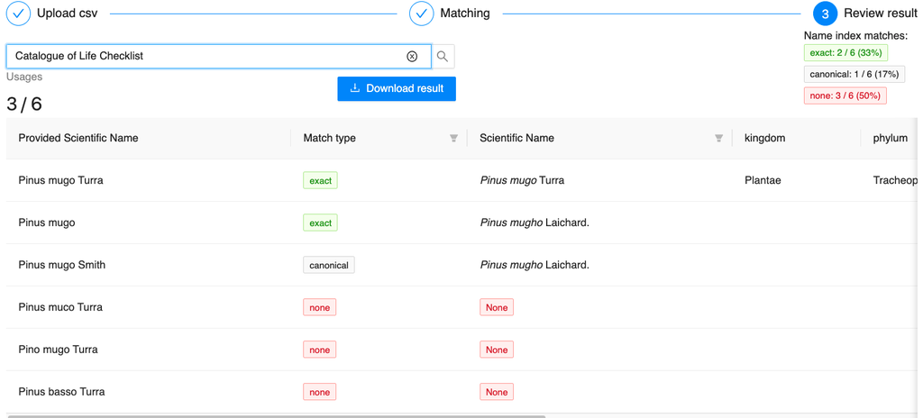

```python
from IPython.display import Image
Image(filename='/Users/sharifislam/Downloads/notebooks/CoL-envri-test.png')
```

The above output can be downloaded as csv

```
"providedScientificName","matchType","nameIndexId","taxonId","parentTaxonId","scientificName","kingdom","phylum","class","order","family","genus"
"Pinus mugo Turra","exact","66724","4J2CJ","6QPY","Pinus mugo Turra","Plantae","Tracheophyta","Pinopsida","Pinales","Pinaceae","Pinus"
"Pinus mugo","exact","66723","29c6ad59-9c37-488c-a092-e85d7b3986dd","42317bc2-390d-49bf-95b3-f06a29141fba","Pinus mugho Laichard.","","","","","",""
"Pinus mugo Smith","canonical","66723","29c6ad59-9c37-488c-a092-e85d7b3986dd","42317bc2-390d-49bf-95b3-f06a29141fba","Pinus mugho Laichard.","","","","","",""
"Pinus muco Turra","none","","","","","","","","","",""
"Pino mugo Turra","none","","","","","","","","","",""
"Pinus basso Turra","none","","","","","","","","","",""
```

### LifeWatch

LifeWatch Taxon match service:

https://lifewatch.be/data-services/

For this tool, you will need to login and submit a job. There are several different Taxon backbone and services can be selected at the same time. No API. This tool let's you select different backbone such as GNI, IPNI. After the job runs, the result is presented the following way:

```
scientificname  required_fields_check   datasetname_fuzzy_col   taxonomicstatus_fuzzy_col   taxonrank_fuzzy_col NOTUSED_scientificname  scientificnameid_fuzzy_col  isextinct_fuzzy_col match_type_fuzzy_col    match_count_fuzzy_col   note_fuzzy_col  NOTUSED_scientificname  id_gni  lsid_gni    taxonmatch_note_gni taxonmatch_matchcount_gni   id_itis name_itis   status_name_itis    taxonmatch_note_itis    taxonmatch_matchcount_itis  guid_pesi   valid_name_pesi valid_guid_pesi status_pesi valid_authority_pesi    match_type_pesi taxonmatch_matchcount_pesi  taxonmatch_note_pesi
"Pinus mugo Turra"  1                                   "Empty response"    "Pinus mugo Turra"  1583131 urn:lsid:globalnames.org:index:b5948654-7d7c-5eb0-874b-a3a00dd07c3b "Exact match"   1               "No exact match found"      E4C17C46-BC16-4EA9-8A18-0D9EE84E8F8F    "Pinus mugo"    E4C17C46-BC16-4EA9-8A18-0D9EE84E8F8F    accepted    Turra   exact   1   "One match found"
"Pinus mugo "   1                                   "Empty response"    "Pinus mugo"    333461urn:lsid:globalnames.org:index:2f24b92e-3f06-5367-a0c0-d1458e41d533   "Exact match"   1               "No exact match found"      E4C17C46-BC16-4EA9-8A18-0D9EE84E8F8F    "Pinus mugo"    E4C17C46-BC16-4EA9-8A18-0D9EE84E8F8F    accepted    Turra   exact   1   "One match found"
"Pinus mugo Smith"  1                                   "Empty response"            "No match found"    0               "No exact match found"      E4C17C46-BC16-4EA9-8A18-0D9EE84E8F8F    "Pinus mugo"    E4C17C46-BC16-4EA9-8A18-0D9EE84E8F8F    accepted    Turra   exact   1   "One match found"
"Pinus muco Turra"  1                                   "Empty response"            "No match found"    0               "No exact match found"      E4C17C46-BC16-4EA9-8A18-0D9EE84E8F8F    "Pinus mugo"    E4C17C46-BC16-4EA9-8A18-0D9EE84E8F8F    accepted    Turra   near_1  1   "One match found"
"Pino mugo Turra"   1                                   "Empty response"            "No match found"    0               "No exact match found"                              0   "No match found"
"Pinus basso Turra" 1                                   "Empty response"            "No match found"    0               "No exact match found"                              0   "No match found"
```

### NCBI Taxonomy

Python library

```python
!ncbi-taxonomist --verbose resolve --names 'Pinus mugo Turra'
```

```
2022-01-25 14:42:50,151 MainThread [INFO] ncbitaxonomist.resolve.resolver.Resolver: {"resolving": "names", "failed": ["Pinus mugo Turra"]}
```

```python
# without the author string
!ncbi-taxonomist resolve --names 'Pinus mugo'|jq
```

```
{
  "mode": "resolve",
  "query": "Pinus mugo",
  "cast": "taxon",
  "taxon": {
    "taxid": 28528,
    "rank": "species",
    "names": {
      "Pinus mugo": "scientific_name",
      "Pinus montana": "Synonym",
      "mountain pine": "CommonName",
      "mugo pine": "CommonName"
    },
    "parentid": 139271,
    "name": "Pinus mugo"
  },
  "lineage": [
    {
      "taxid": 28528,
      "rank": "species",
      "names": {
        "Pinus mugo": "scientific_name",
        "Pinus montana": "Synonym",
        "mountain pine": "CommonName",
        "mugo pine": "CommonName"
      },
      "parentid": 139271,
      "name": "Pinus mugo"
    },
    {
      "taxid": 139271,
      "rank": "subgenus",
      "names": {
        "Pinus subgen. Pinus": "scientific_name"
      },
      "parentid": 3337,
      "name": "Pinus subgen. Pinus"
    },
    {
      "taxid": 3337,
```

[output cut: 129 more lines]

```
      },
      "parentid": 131567,
      "name": "Eukaryota"
    },
    {
      "taxid": 131567,
      "rank": "no rank",
      "names": {
        "cellular organisms": "scientific_name"
      },
      "parentid": null,
      "name": "cellular organisms"
    }
  ]
}
```

```python
# Incorrect author
!ncbi-taxonomist resolve --names 'Pinus mugo Smith'|jq
```

```
2022-01-25 14:42:54,779 MainThread [WARNING] entrezpy.conduit.Conduit: {"empty response": {"queryid": "ePDl7eTKTNmuWlXJOWNafg==", "action": "skip"}}
```

```python
# spelling mistake
!ncbi-taxonomist resolve --names 'Pinus muco Turra'|jq
```

```
2022-01-25 14:42:57,084 MainThread [WARNING] entrezpy.conduit.Conduit: {"empty response": {"queryid": "3-0Z6m5DRd-1ZQPb229lRA==", "action": "skip"}}
```

```python
# without the authority string
!ncbi-taxonomist resolve --names 'Pino mugo Turra'|jq
```

```
2022-01-25 14:42:58,422 MainThread [WARNING] entrezpy.conduit.Conduit: {"empty response": {"queryid": "ZXurifJOQnWchhPyo5Knkg==", "action": "skip"}}
```

```python
# without the authority string
!ncbi-taxonomist resolve --names 'Pinus basso Turra'|jq
```

```
2022-01-25 14:42:59,738 MainThread [WARNING] entrezpy.conduit.Conduit: {"empty response": {"queryid": "U4koVclAQsCElUWij77sCA==", "action": "skip"}}
```

## A few other services to compare

#### NomenMatch

A few other web friendly tools http://match.taibif.tw/about.html "NomenMatch is a tool for taxonomists to match a set of species names against other sets with certain authority. It returns matched names, ids, usage status, and links to original sources. So not only the matched results, users can also know about differences of name usage among different sources. This is important because we believe that there is no absolute right or wrong, and only different perspectives in taxonomy. This tool provides easily references for taxonomists."

Test query link: http://match.taibif.tw/api.php?names=Pinus%20mugo%20Turra|Pinus%20mugo%20Smith|Vicia%20faba%20L.|Vicia%20faba%20S.|Vicia%20faba|Vicia%20fava

#### Taxonomic name resolution service

2013 paper https://dx.doi.org/10.1186%2F1471-2105-14-16

https://tnrs.biendata.org/#

This has a score but uses different backbone

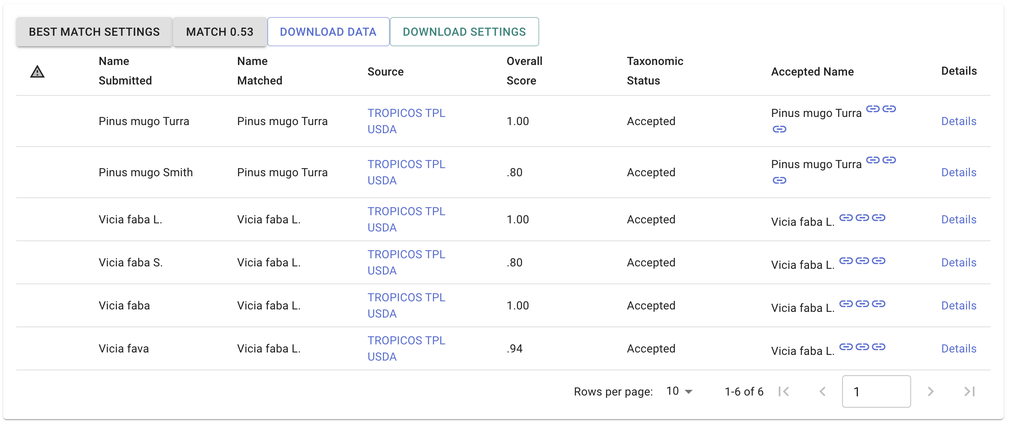

```python
Image(filename='/Users/sharifislam/tnrs-results.png')
```

#### EU-NOMEN

EU-NOMEN/PESI project http://www.eu-nomen.eu/portal/index.php

EU-nomen enables the correct use of species names and their classification, to more accurately manage information on animals and plants. This is the first all-taxa inventory for European species.

```python
import requests
from requests.structures import CaseInsensitiveDict
url = "http://www.eu-nomen.eu/portal/rest/PESIRecordsByName/Vicia%20Faba?like=true&offset=1"
headers = CaseInsensitiveDict()
headers["Accept"] = "application/json"


resp = requests.get(url, headers=headers)
print(resp.status_code)
```

```
200
```

```python
json.loads(resp.text)
```

```
[{'GUID': '862AC002-BF8C-4E63-B349-4DD2056B611B',
  'url': 'http://www.eu-nomen.eu/portal/taxon.php?GUID=862AC002-BF8C-4E63-B349-4DD2056B611B',
  'scientificname': 'Vicia faba',
  'authority': 'L.',
  'status': 'accepted',
  'rank': 'Species',
  'valid_guid': '862AC002-BF8C-4E63-B349-4DD2056B611B',
  'valid_name': 'Vicia faba',
  'valid_authority': 'L.',
  'kingdom': 'Plantae',
  'phylum': 'Tracheophyta',
  'class': 'Magnoliopsida',
  'order': 'Fabales',
  'family': 'Fabaceae',
  'genus': 'Vicia',
  'citation': 'ILDIS World Database of Legumes  2010. (copyright © ILDIS). Vicia faba L.. Accessed through: Euro+Med PlantBase at http://ww2.bgbm.org/euroPlusMed/PTaxonDetail.asp?UUID=862AC002-BF8C-4E63-B349-4DD2056B611B',
  'match_type': 'like'},
 {'GUID': 'FA67D28A-BE85-46DE-BB21-54C5346EA1EE',
  'url': 'http://www.eu-nomen.eu/portal/taxon.php?GUID=FA67D28A-BE85-46DE-BB21-54C5346EA1EE',
  'scientificname': 'Vicia faba subsp. faba',
  'authority': 'L.',
  'status': 'accepted',
  'rank': 'Subspecies',
  'valid_guid': 'FA67D28A-BE85-46DE-BB21-54C5346EA1EE',
  'valid_name': 'Vicia faba subsp. faba',
  'valid_authority': 'L.',
  'kingdom': 'Plantae',
  'phylum': 'Tracheophyta',
  'class': 'Magnoliopsida',
  'order': 'Fabales',
  'family': 'Fabaceae',
  'genus': 'Vicia',
  'citation': 'ILDIS World Database of Legumes  2010. (copyright © ILDIS). Vicia faba L. subsp. faba. Accessed through: Euro+Med PlantBase at http://ww2.bgbm.org/euroPlusMed/PTaxonDetail.asp?UUID=FA67D28A-BE85-46DE-BB21-54C5346EA1EE',
  'match_type': 'like'},
 {'GUID': 'AB4C5348-8C21-4528-B28C-C54BF73133B8',
  'url': 'http://www.eu-nomen.eu/portal/taxon.php?GUID=AB4C5348-8C21-4528-B28C-C54BF73133B8',
  'scientificname': 'Vicia faba var. minor',
  'authority': 'Beck',
  'status': 'accepted',
  'rank': 'Variety',
  'valid_guid': 'AB4C5348-8C21-4528-B28C-C54BF73133B8',
  'valid_name': 'Vicia faba var. minor',
  'valid_authority': 'Beck',
  'kingdom': 'Plantae',
  'phylum': 'Tracheophyta',
  'class': 'Magnoliopsida',
  'order': 'Fabales',
  'family': 'Fabaceae',
  'genus': 'Vicia',
  'citation': 'ILDIS World Database of Legumes  2010. (copyright © ILDIS). Vicia faba var. minor Beck. Accessed through: Euro+Med PlantBase at http://ww2.bgbm.org/euroPlusMed/PTaxonDetail.asp?UUID=AB4C5348-8C21-4528-B28C-C54BF73133B8',
  'match_type': 'like'}]
```

```python
for i in json.loads(resp.text):
    print(i['scientificname']+" "+i['valid_name']+" "+i['valid_authority'] )
```

```
Vicia faba Vicia faba L.
Vicia faba subsp. faba Vicia faba subsp. faba L.
Vicia faba var. minor Vicia faba var. minor Beck
```

### Comparison Table

Comparison of some of the tools mentioned above.

[output not shown]